# Economic Growth

In this document, I outline the most prominent models that attempt to explain the determinants of economic growth. A basic knowledge of calculus is necessary to interpret many of their features.

## Growth Measurement

Real Gross Domestic Product (real GDP) is the metric used to measure economic output $-$ it is the value of all final goods and services produced by an economy. "Real" GDP indicates that the measure accounts for changes in a currency's purchasing power (inflation) $-$ from here on I will simply use GDP when referring to real GDP. GDP is signified as $Y$ in mathematical notation. GDP can be calculated using three approaches, all of which produce equivalent results, barring measurement error:

- Expenditure:

  $Y$ = Consumption + Investment + Government Spending + (Exports - Imports)
- Production:

  $Y$ = Total goods/services produced - Intermediate use of goods/services in production
- Income:

  $Y$ = Employee compensation + Gross operating surplus + Gross mixed income + (Taxes - Subsidies)

GDP per capita is also used as an economic output metric. It is GDP divided by the number of people in the economy.

GDP per capita = $\cfrac{Y}{N}$, where N is the population size.

Economic growth can be defined as the percent change of GDP for a given period of time. It is calculated as change in GDP across a period of time, divided by the initial level of GDP. This is important to remember, as modern models use economic growth as a measure, not simply the change in GDP over time.

Economic Growth $ = \cfrac{\bigtriangleup Y}{Y} = \cfrac{Y_{t+1} - Y_t}{Y_t}$

## Models

### Simple Exponential Growth Model (1798)

In 1798, Robert Malthus proposed that the human population grows at a rate proportional to its current level. Mathematicians then formalized this assertion:

$\cfrac{dP}{dt} = rP_t$

This states that the change in population is equal to the population level at a given time, $P_t$, multiplied by a constant, $r$, which is the growth rate of the population. Using the established growth rate equation:

$\cfrac{dP}{dt} = \cfrac{\bigtriangleup P}{P_t} {P_t} = \bigtriangleup P$

This model is important as it gives us a mathematical function to describe changes in a value in percentage terms, with $r$ being the percent change in the population level. We may also want to evaluate the above function at a specific point in time. To do so, we need to solve the differential equation:

$\cfrac{dP}{dt} = rP_t$

Rearrange terms:

$\cfrac{1}{P_t} dP = r dt$

Integrate:

$\int \cfrac{1}{P_t} dP = \int r dt$

$\ln P_t = c + rt$, where c is a constant.

Apply exponential:

$|P_t| = e^{c + rt} = e^{c}e^{rt}$

Given that an exponential function cannot output a negative value, we drop the absolute value:

$P_t = e^{c}e^{rt}$

Given that $e^{c}$ will also output a constant, we can say $e^{c} = C$, where $C$ is a constant.

$P_t = Ce^{rt}$

If we evaluate at $t=0$, $P_t = C$. Therefore, $C$ is the population level at time $t=0$, which we denote as $P_0$:

$P_t = P_0 e^{rt}$

This final equation is important, as it asserts that the initial differential equation, $\cfrac{dP}{dt} = rP_t$, describes an exponential function. Below is its graphical form:

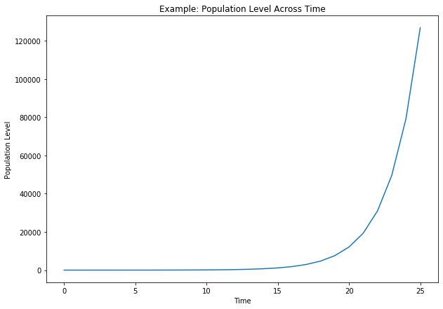

```python
#Import libraries
import matplotlib.pyplot as plt
import numpy as np
import math
import pandas as pd

#Function to output population values across time using exponential growth model
def exponential_growth(starting_population, rate, time):

    population_across_time = [starting_population]

    for time_step in range(time):
        population_across_time.append(population_across_time[time_step] + \
                                      (rate * population_across_time[time_step]))

    return population_across_time

#Evaluate function using chosen inputs
function_evaluation = exponential_growth(1, .6, 25)

#Plot function evaluation
plt.figure(figsize=(10,7))
plt.plot(function_evaluation)
plt.title("Example: Population Level Across Time")
plt.ylabel("Population Level")
plt.xlabel("Time")
plt.show()
```

For an empirical comparison, I plot England's population level and GDP from 1270 to 2016. This data is made publicly available by the Bank of England.

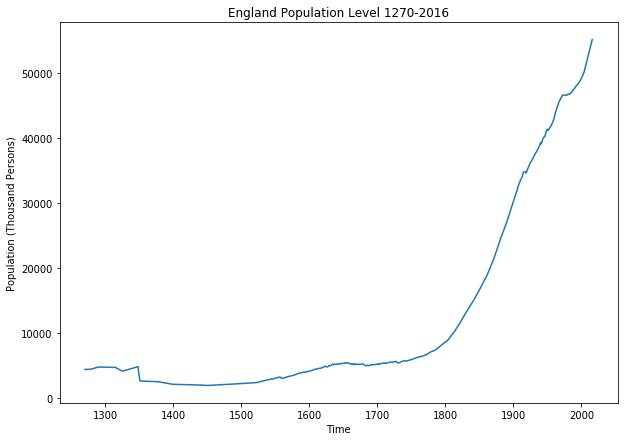

```python
#Import Dataset
England_Data = pd.read_excel('England_GDP_Pop_1270_2016.xlsx')

#Graph Population Data
plt.figure(figsize=(10,7))
plt.plot(England_Data['Time'], England_Data['England Population'])
plt.title('England Population Level 1270-2016')
plt.xlabel('Time')
plt.ylabel('Population (Thousand Persons)')
plt.show()
```

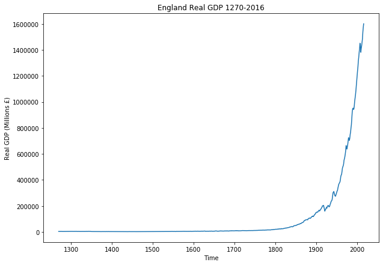

```python
#Graph GDP Data
plt.figure(figsize=(10,7))
plt.plot(England_Data['Time'], England_Data['England Real GDP'])
plt.title('England Real GDP 1270-2016')
plt.xlabel('Time')
plt.ylabel('Real GDP (Millions £)')
plt.show()
```

The models discussed in this paper attempt to explain the exponential growth of GDP. Below, I plot the annual percentage change in England's GDP from 1270 to 2016 $-$ the black horizontal line represents a zero percentage change. This provides a visual depiction of economic growth across time.

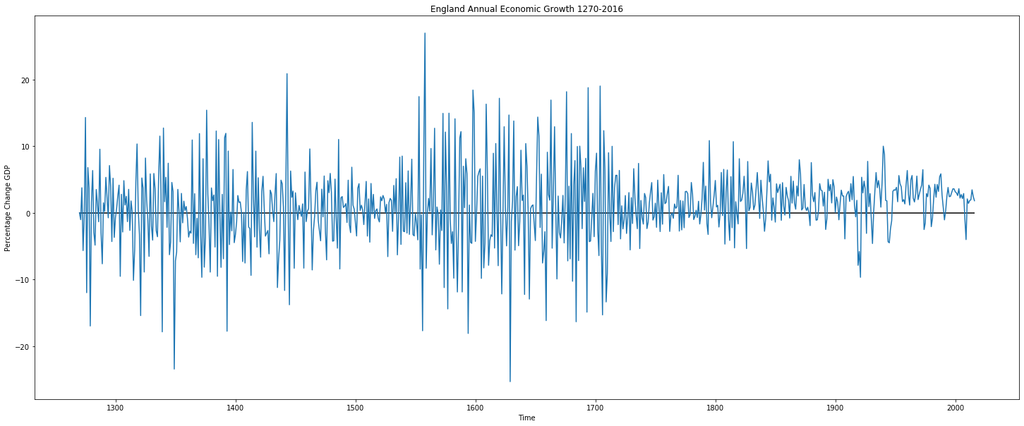

```python
#Graph GDP Growth Data
plt.figure(figsize=(25,10))
plt.plot(England_Data['Time'], England_Data['England Real GDP % Change'])
#plt.hlines(np.average(England_Data['England Real GDP % Change']), 1270, 2016)
plt.hlines(0, 1270, 2016)
plt.title('England Annual Economic Growth 1270-2016')
plt.xlabel('Time')
plt.ylabel('Percentage Change GDP')
plt.show()
```

### Harrod-Domar Model (1939)

The Harrod-Domar Model uses a production function to describe aggregate output $-$ it claims that GDP is dependent on capital stock $K$ and the capital to output ratio $\upsilon$.

$Y = \cfrac{K}{\upsilon}$

Capital stock is any reproducible object that is used, but not depleted, in production $-$ examples being machinery, equipment, and infrastructure. The capital to output ratio is, for a given amount of input capital, the value of the associated production output; in essence, it measures the productivity of capital. For $0<\upsilon<1$, the value of the output is greater than the value of the capital input.

The model also includes how capital stock changes across time. From one time period to the next, the change in capital stock is dependent on gross investment $I$, depreciation $\delta$, and the current value of capital stock $K$.

$\bigtriangleup K = I - (\delta K)$

The model abides by the identity that investment equals all money that is not spent on consumption in the current time period. In other words, investment equals savings, $S$ $-$ this is calculated using the savings rate, $s$, which is a measure of how much is saved from current GDP.

$I = S = sY$

Depreciation $\delta$ is a measure of how much capital is used up/destroyed during production from one period to the next.

To calculate economic growth, $\cfrac{\bigtriangleup Y}{Y}$, we calculate the change in GDP and divide by the current level of GDP:

$\cfrac{\bigtriangleup Y}{Y} = \cfrac{\bigtriangleup K}{Y\upsilon}$

Replace with the second equation:

$\cfrac{\bigtriangleup Y}{Y} = \cfrac{I - (\delta K)}{Y\upsilon}$

Replace with the third equation:

$\cfrac{\bigtriangleup Y}{Y} = \cfrac{sY - (\delta K)}{Y\upsilon}$

Simplify:

$\cfrac{\bigtriangleup Y}{Y} = \cfrac{s}{\upsilon} - \delta$

The Harrod-Domar Model claims that capital accumulation is the core determinant of economic growth. To accumulate capital, it stresses that a high savings rate, $s$, and high productivity of capital (capital to output ratio) $\upsilon$, are paramount.

Although the model identifies a central factor in economic growth, capital accumulation, its restrictive assumptions hamper its accuracy. A constant level of capital productivity, $\upsilon$, is a major weakness of the model that hinders its ability to forecast long-run growth. In addition, it assumes fixed capital-labor and labor-output ratios, which only allow a constant-growth equilibrium to be established if all three variables grow at the same rate, which is not supported by empirical studies. The model also assumes that the economy is financially closed and only has one sector. In all, it performs relatively well in predicting growth within a two-year time span, however, it is not a strongly generalized economic growth model.

### Solow-Swan Model (1956)

Many view the Solow-Swan Model as an extension to the Harrod-Domar Model. Solow-Swan claims that GDP is dependent on capital stock $K$, number of workers $N$, and technological change $A$.

A key difference between the Solow-Swan Model and the Harrod-Domar Model is their view on returns to capital. The Harrod-Domar Model assumes constant returns to increasing capital stock, signified by $\upsilon$, while the Solow-Swan Model claims diminishing returns to capital, shown in the neoclassical Cobb-Douglass production function. Diminishing returns to capital states that although each additional unit of capital increases total output, it increases output less than the prior unit of additional capital. The rationale for diminishing returns is that workers find it increasingly difficult to utilize and manage additional units of capital, as humans have limited physical and cognitive ability.

Solow-Swan is also many times written in continuous time, indicated by the $t$ subsrcipts on each variable. The $\alpha$ and $1-\alpha$ exponents enforce constant returns to scale for the aggregate factors of production, and subsequently diminishing returns to scale for capital and labor, separately.

$Y_t = f(K_t, A_t, N_t) = K_t^{\alpha} [A_t N_t]^{1-\alpha}$

Solow-Swan is written in terms of per capita values:

$y_t = \cfrac{Y_t}{N_t}$

$k_t = \cfrac{K_t}{N_t}$

The per capita variables are then placed into the above function:

$y_t = k_t^{\alpha} [A_t]^{1-\alpha}$

First, we differentiate with respect to time $-$ in this case we use Newton's dot notation:

$\cfrac{\dot y_t}{y_t} = \alpha \cfrac{\dot k_t}{k_t} + (1-\alpha) \cfrac{\dot A_t}{A_t}$

Using the basic growth function, $A_t = A_0 e^{g_A t}$, we approximate: $\cfrac{\dot A_t}{A} = g_A$.

$g_A$ is the growth rate of technological change $-$ we place this in the equation:

$\cfrac{\dot y_t}{y_t} = \alpha \cfrac{\dot k_t}{k_t} + (1-\alpha)g_A$

Another key feature of Solow-Swan is that it implies a balanced long-run growth path $-$ meaning that output per capita and capital per capita grow at nearly the same rate. This is shown in certain empirical studies, popularized by Kaldor. This feature does not necessarily contradict the diminishing returns to capital per capita assumption, as returns to capital refers to $\bigtriangleup Y$, while balanced growth refers to $\cfrac{\bigtriangleup Y}{Y}$.

$\cfrac{\dot y_t}{y_t} \approx \cfrac{\dot k_t}{k_t} = g_{y,k}$

However, this allows us to simplify:

$g_{y,k} = \alpha g_{y,k} + (1-\alpha)g_A$

$(1-\alpha)g_{y,k} = (1-\alpha)g_A$

Achieving the final equation:

$g_{y,k} = g_A$

Indeed, the Solow-Swan Model concludes that technological growth is the foremost factor affecting economic growth. This particular version of the model specifies labor-augmenting technology $-$ objects or methods that increase returns to labor $-$ as the source of technological growth, however, capital-augmenting technologies can also be included. Diminishing returns to capital claims that increasing capital accumulation becomes less productive for industrialized nations, and technological growth is the feature that explains continual GDP growth for these countries. Despite being the most influential economic growth model, certain characteristics such as the one-sector assumption and the passive determination of investment limit its specificity. Taking technological growth as an exogenous variable $-$ one that is determined independently of the model or any of its other variables $-$ is a limitation that current models attempt to explore.

### Endogenous Growth Model (1986)

Endogenous growth models build on Solow-Swan by providing functions to determine inputs such as the savings rate, labor supply growth rate, and most importantly, technological change. Romer's 1990 paper endogenized technological growth by including knowledge as an input to production. Romer claimed that ideas and knowledge have constant returns because they are non-rival, and therefore the entire production function has increasing returns to scale to a broad concept of investment activity that drives both physical capital accumulation and the advance of productivity. Human capital formation often plays a prominent role in endogenous growth models. By releasing the economy from diminishing returns to investment, these models have helped explain why traditionally high-output nations were capable of continual economic growth.

### Institutions Model (1991)

The institutional model of growth claims that the frameworks of constraining social interaction (governments, legal systems, norms) that incentivize productive economic activity improve long-run economic growth. Examples of institutional frameworks are currency, property rights, contract enforcement, and government regulation. Efficient institutions also disincentivize predatory behavior, such as rent-seeking, corruption, and theft.

North (1991) asserts that innovations in 11$^{th}$-16$^{th}$ century Western European institutions increased economies of scale of trade. These innovations included bills of exchange, the ability to print and publish prices, and merchant insurance. The incentives created through these institutional trading technologies increased profitability and the volume of mutually beneficial transactions. Hall and Jones (1999) performs a cross-national study and conclude that social infrastructure, as measured by the GAPD index and openness to trade, drives both investment in physical and human capital, and it also improves productivity when using these inputs.

## Conclusion

Despite the range of models that have been developed to explain economic growth, two factors are consistent as having causal impact on increasing output:

1. Capital Accumulation
2. Technological/Productivity Improvements

Additional explanatory variables are continually being assessed, such as geography and trade openness. These theories continue to be refined and compared with empirical study, in hopes of achieving a robust model of economic growth.